# Analysis of Consumer Walking Habits from Fit Bit Technology Data Set

Dr. Sumanth Swaminathan

October 18, 2015

## Introduction

This study is meant to answer basic questions about the movement habits of populations who monitor their daily steps using devices such as fitbit, Nike Fuelband, or Jawbone Up. We present a basic exploratory data analysis with accompanying visualization and answer the following questions:

1. What is the mean total number of steps taken per day ignoring missing data
2. What is the pattern of daily step habits and the time of day when the average number of steps taken are a maximum.
3. What is the difference in consumer walking habits between weekdays and weekends.

## Analysis and Visualization

The data set used for this study is collected from Fit Bit, Jawbone Up, and Nike Fuelband devices. The specific variables included in the data set are “steps”" taken, 5 minute time “interval” of collection, and “date” collected. More information as well as the original data set can be found in the following Github Repo: https://github.com/rdpeng/RepData_PeerAssessment1. **Note that all data on steps are rounded after calculations as fractional steps are not of interest in this report.**

### Mean Total Number of Steps Taken per Day

We start by reading the data into R and removing missing entries (indicated by “NA”). Next, we calculate the total steps taken on each particular date and average the results to find the average total steps taken per day. Finally, a histogram of the Total Daily Step data is presented. Calculations as well as the accompanying histogram are shown below.

```r
library(timeDate)
library(plyr)
library(ggplot2)
library(lattice)

masterdata=read.csv("activity.csv") #load data
masterdatanew=masterdata #copy of masterdata

#Part 1: Calculate mean number of daily steps

Dfnew = masterdata[!is.na(masterdata$steps),] #Apply mean function to data set by unique day
Dfsteptot=ddply(Dfnew,~date,summarise,totsteps=sum(steps)) #Create data table with total steps taken on each day
print(round(mean(Dfsteptot$totsteps))) #print mean of daily total steps as integer
```

```
## [1] 10766
```

```r
print(round(median(Dfsteptot$totsteps))) #print median of daily total steps as integer
```

```
## [1] 10765
```

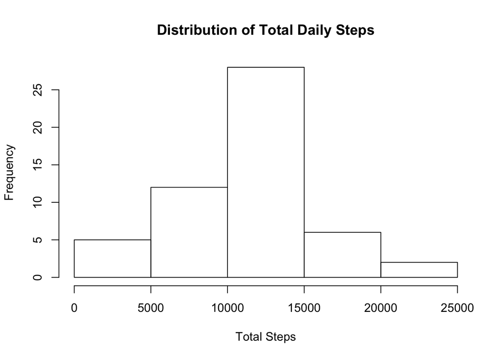

```r
hist(Dfsteptot$totsteps,xlab="Total Steps",main="Distribution of Total Daily Steps") #Create histogram of Total Step Frequency
```

### Daily Time Interval Walking Data

We extend our analysis to include detail of walking habits in 5 minute time intervals of each day of data collection. We start by finding the average number of steps taken in any given 5 minute time interval during the course of the data collection. We then use this information to determine the time of day at which the largest number of steps are taken. A plot of the time interval data and accompanying calculation are shown below:

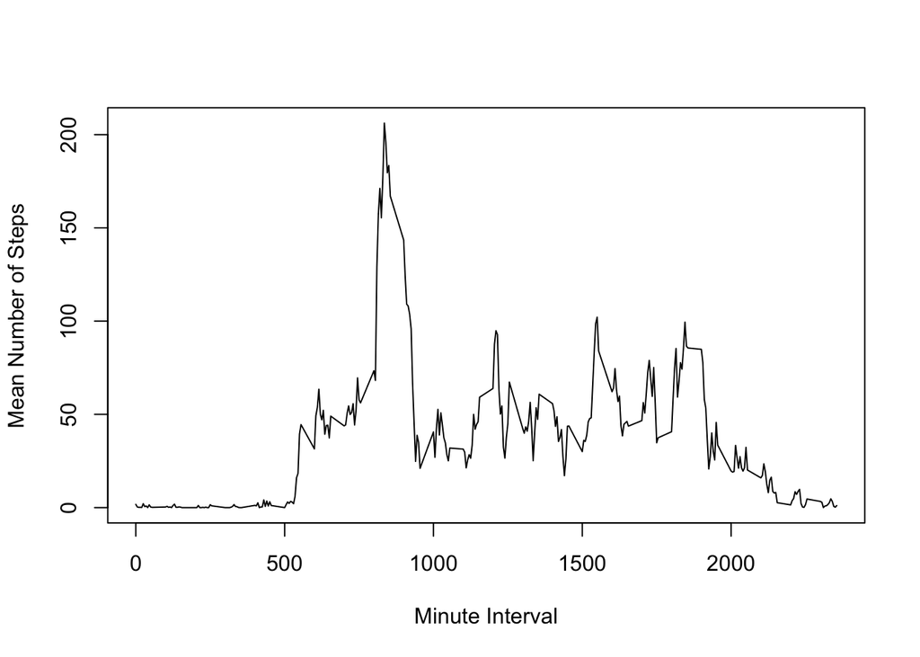

```r
Dfintmean=ddply(Dfnew,~interval,summarise,meansteps = mean(steps)) #Create data table with total steps taken in a given time interval
plot(Dfintmean$interval,Dfintmean$meansteps, ylab="Mean Number of Steps", xlab="Minute Interval", type='l') #Plot of Mean Number of Steps vs 5 Minute interval
```

```r
print(Dfintmean[Dfintmean$meansteps==max(Dfintmean$meansteps),]$interval) #Report the time interval that contained the largest mean number of steps
```

```
## [1] 835
```

### Analysis with Inclusion of missing data

To get a different perspective of the data set, we go back and include all of the missing data in the original set. The strategy for doing analysis on the missing data is to replace the NA values with the mean number of steps taken in that 5 minute time interal using the present data (which was calculated in the previous section). Afterward, we recalculate the mean and median total steps by date as well as the step distribution.

```r
TotNa = length(masterdata[is.na(masterdata$steps),1]) #Total Number of NAs in dataset
NAs=is.na(masterdata$steps) #find the indices of the na values in masterdata
#Fill in missing values with average steps at that 5 minute interval from other data
masterdatanew$steps[NAs] <- round(Dfintmean[match(masterdatanew$interval[NAs], Dfintmean$interval),]$meansteps)
steptot=ddply(masterdatanew,~date,summarise,totsteps=sum(steps)) #Create data table with total steps taken on each day
print(round(mean(steptot$totsteps))) #print mean of daily total steps as integer
```

```
## [1] 10766
```

```r
print(round(median(steptot$totsteps))) #print median of daily total steps as integer
```

```
## [1] 10762
```

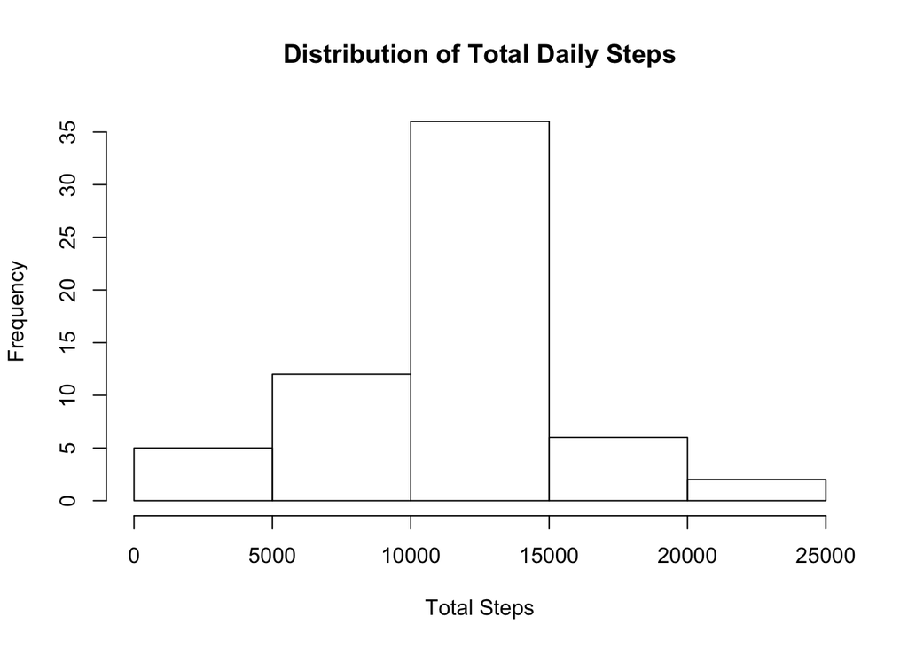

```r
hist(steptot$totsteps,xlab="Total Steps",main="Distribution of Total Daily Steps") #Create histogram of Total Step Frequency
```

The above analysis actually shows that the strategy for imputing the missing data changed the mean and median in a very minor way (mostly because the missing values were replaced by summary statistics)

### Weekday Vs Weekend Walking Activity

The final analysis we do includes a study of the difference in step habits between week day and weekends. To do this analysis, we create a new variable indicating “weekday” vs “weekend”, and we average teh total number of steps taken in any given 5 minute interval across weekdays and weekends. The plot shown shows the 5 minute time interval walking habits for both weekdays and weekends.

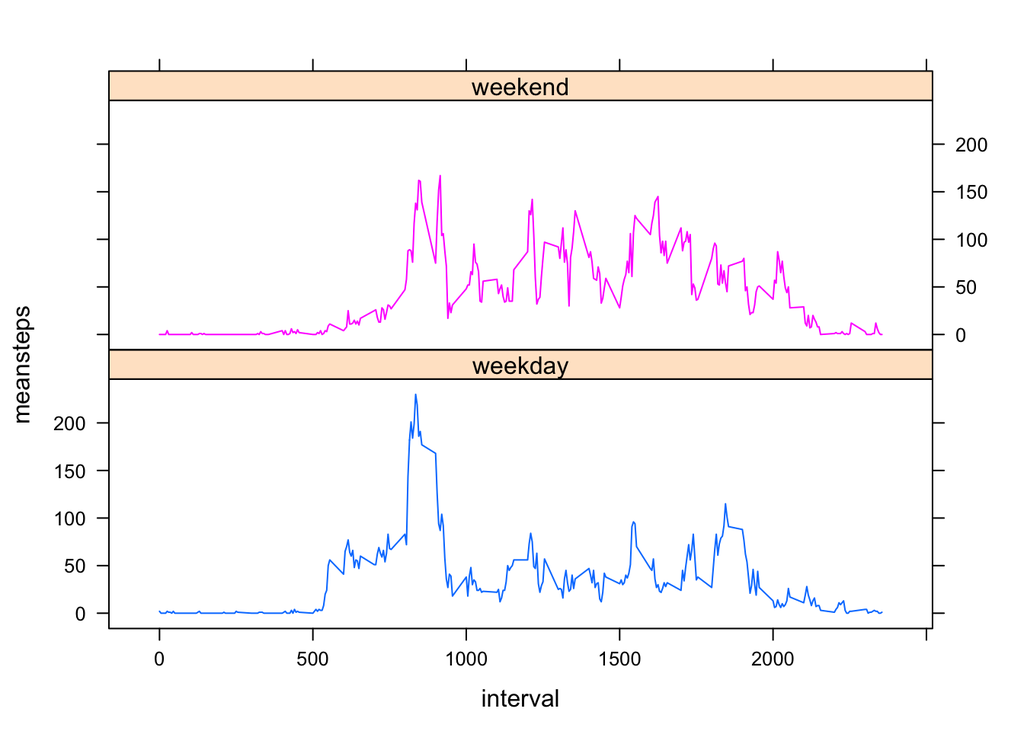

```r
#Assign "weekday" or "weekend" labels to the appropriate date
masterdatanew$daytype=masterdatanew$steps #create new data column called day type with some values
masterdatanew[isWeekday(masterdatanew$date, wday=1:5),]$daytype="weekday" #fill in "weekday" for weekday dates
masterdatanew[!isWeekday(masterdatanew$date, wday=1:5),]$daytype="weekend" #fill in "weekend" for weekend dates

#Average Data over minute interval by day type
mdat1 = masterdatanew[masterdatanew$daytype=="weekday",]
mdat2 = masterdatanew[masterdatanew$daytype=="weekend",]
DtF1 = ddply(mdat1,~interval,summarise,meansteps = round(mean(steps)),daytype="weekday")
DtF2 = ddply(mdat2,~interval,summarise,meansteps = round(mean(steps)),daytype="weekend")
DtFF = rbind(DtF1,DtF2)

#Create Panel Plot of Results

latplot= xyplot(meansteps~interval|daytype, ## conditional formula to get 2 panels
       data=DtFF,       ## data
       type='l',        ## line type for plot
       groups=daytype,     ## group t0 get differents colors
       layout=c(1,2))   ## equivalent to par or layout
       ylab="Mean Total Steps"

print(latplot)
```

## Conclusions and Closing Remarks

In short, the walking habits of those consumers of fit bit type technology yields fairly intuitive trends on daily walking habits in addition to interesting quantitative information about the actual number of steps taken on different days and at different times.